# Spotting

Ember generation and transport

Spotting (ember transport) creates new ignitions downwind of the main fire. This tutorial covers Elmfire.jl’s spotting capabilities.

```julia
using Elmfire
using Plots
using Random
Random.seed!(42)
```

```
TaskLocalRNG()
```

## Spotting Mechanism

Embers (firebrands) are generated by: - Burning vegetation lofted by convection - Higher intensity fires produce more embers - Crown fires generate significantly more embers

## Configuring Spotting

```julia
# Create spotting parameters
spotting_params = SpottingParameters{Float64}(
    mean_distance = 100.0,              # Mean spotting distance (m)
    normalized_variance = 0.5,          # Normalized variance
    ws_exponent = 1.0,                  # Wind speed exponent
    flin_exponent = 0.5,                # Fireline intensity exponent
    nembers_max = 10,                   # Max embers per cell per timestep
    surface_spotting_percent = 1.0,     # Surface fire spotting probability (%)
    crown_spotting_percent = 10.0,      # Crown fire spotting probability (%)
    pign = 50.0,                        # Ignition probability (%)
    min_distance = 10.0,                # Min distance (m)
    max_distance = 2000.0               # Max distance (m)
)
```

```
SpottingParameters{Float64}(100.0, 0.5, 1.0, 0.5, 10, 1.0, 10.0, 50.0, 10.0, 2000.0)
```

## Ember Transport

Embers are transported downwind with distances that scale with wind speed and fireline intensity.

These simulations set `use_sardoy = true`, which draws the distance from the Sardoy (2008) correlation — a lognormal whose parameters come from the fireline intensity and 10 m wind directly. For the chaparral fire below that gives a median throw of about 124 m.

The alternative is the empirical scaling below, where the mean distance is `mean_distance × I^flin_exponent × U^ws_exponent`. Note that `mean_distance` is a *coefficient*, not a distance: with `flin_exponent = 0.5` and a chaparral fireline intensity near 59,000 kW/m, a `mean_distance` of 100 implies a mean throw of hundreds of kilometres, which `max_distance` then truncates. Prefer the Sardoy model unless you have calibrated the coefficient for your own fuels.

The `SpottingParameters` control:

- **mean_distance**: Base spotting distance (m)
- **ws_exponent**: How much wind speed increases distance
- **flin_exponent**: How much intensity increases distance
- **normalized_variance**: Randomness in landing location
- **min_distance / max_distance**: Distance bounds (m)

## Simulation with Spotting

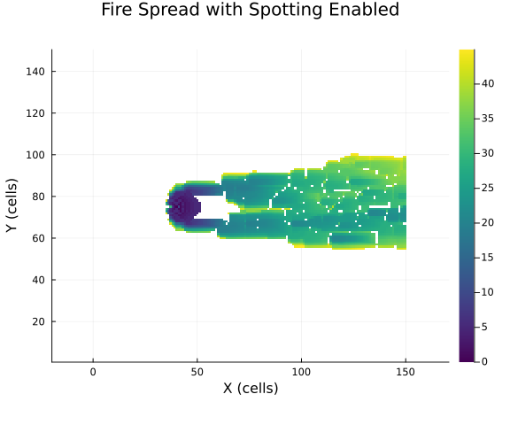

```julia
ncols, nrows = 150, 150
cellsize = 30.0

state = FireState{Float64}(ncols, nrows, cellsize)
fuel_table = create_standard_fuel_table(Float64)
fuel_ids = fill(4, ncols, nrows)  # Chaparral (high intensity)

slope = zeros(Float64, ncols, nrows)
aspect = zeros(Float64, ncols, nrows)

weather = ConstantWeather{Float64}(
    wind_speed_mph = 20.0,
    wind_direction = 270.0,
    M1 = 0.04, M10 = 0.06, M100 = 0.08,
    MLH = 0.40, MLW = 0.70
)

config = SimulationConfig{Float64}(
    enable_crown_fire = false,
    enable_spotting = true,
    spotting_params = spotting_params,
    use_sardoy = true
)

ignite!(state, 40, 75, 0.0)
weather_interp = create_constant_interpolator(weather, ncols, nrows, cellsize)

simulate_full!(state, fuel_ids, fuel_table, weather_interp, slope, aspect,
    0.0, 45.0; config = config, rng = MersenneTwister(42))

# Visualize
toa = copy(state.time_of_arrival)
toa[toa .< 0] .= NaN

heatmap(toa',
    title = "Fire Spread with Spotting Enabled",
    xlabel = "X (cells)",
    ylabel = "Y (cells)",
    color = :viridis,
    aspect_ratio = 1,
    size = (600, 500)
)
```

## With vs Without Spotting

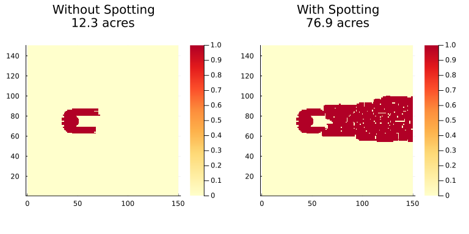

```julia
# Without spotting
state_no_spot = FireState{Float64}(ncols, nrows, cellsize)
ignite!(state_no_spot, 40, 75, 0.0)
config_no_spot = SimulationConfig{Float64}(enable_spotting = false)

simulate_full!(state_no_spot, fuel_ids, fuel_table, weather_interp, slope, aspect,
    0.0, 45.0; config = config_no_spot)

# With spotting
state_spot = FireState{Float64}(ncols, nrows, cellsize)
ignite!(state_spot, 40, 75, 0.0)

simulate_full!(state_spot, fuel_ids, fuel_table, weather_interp, slope, aspect,
    0.0, 45.0; config = config, rng = MersenneTwister(42))

p1 = heatmap(state_no_spot.burned',
    title = "Without Spotting\n$(round(get_burned_area_acres(state_no_spot), digits=1)) acres",
    color = :YlOrRd, aspect_ratio = 1)

p2 = heatmap(state_spot.burned',
    title = "With Spotting\n$(round(get_burned_area_acres(state_spot), digits=1)) acres",
    color = :YlOrRd, aspect_ratio = 1)

plot(p1, p2, layout = (1, 2), size = (800, 400))
```

## Ember Generation

The number of embers depends on:

- **Fireline intensity**: Higher intensity fires loft more embers
- **Fire type**: Crown fires generate more embers than surface fires
- **spotting_params.nembers_max**: Upper limit on embers per cell
- **spotting_params.surface_spotting_percent / crown_spotting_percent**: Probability of spotting

## Long-Range Spotting

Extreme fires can spot miles ahead:

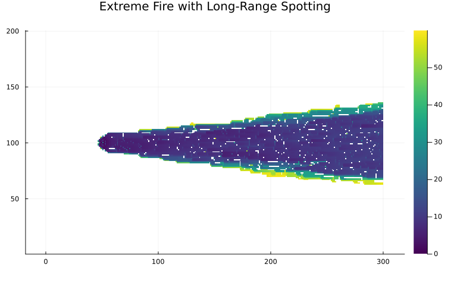

```julia
# High-intensity scenario
ncols_big, nrows_big = 300, 200

state_big = FireState{Float64}(ncols_big, nrows_big, cellsize)
fuel_ids_big = fill(4, ncols_big, nrows_big)
slope_big = zeros(Float64, ncols_big, nrows_big)
aspect_big = zeros(Float64, ncols_big, nrows_big)

extreme_weather = ConstantWeather{Float64}(
    wind_speed_mph = 35.0,
    wind_direction = 270.0,
    M1 = 0.03, M10 = 0.05, M100 = 0.07,
    MLH = 0.35, MLW = 0.60
)

extreme_spotting = SpottingParameters{Float64}(
    mean_distance = 200.0,              # Longer mean distance (m)
    normalized_variance = 0.5,
    ws_exponent = 1.0,
    flin_exponent = 0.5,
    nembers_max = 20,                   # More embers
    surface_spotting_percent = 2.0,
    crown_spotting_percent = 15.0,
    pign = 60.0,                        # Higher ignition probability
    min_distance = 10.0,
    max_distance = 5000.0               # Longer max distance (m)
)

config_extreme = SimulationConfig{Float64}(
    enable_spotting = true,
    spotting_params = extreme_spotting,
    use_sardoy = true
)

ignite!(state_big, 50, 100, 0.0)
weather_interp_big = create_constant_interpolator(extreme_weather, ncols_big, nrows_big, cellsize)

simulate_full!(state_big, fuel_ids_big, fuel_table, weather_interp_big,
    slope_big, aspect_big, 0.0, 60.0;
    config = config_extreme, rng = MersenneTwister(42))

toa = copy(state_big.time_of_arrival)
toa[toa .< 0] .= NaN

heatmap(toa',
    title = "Extreme Fire with Long-Range Spotting",
    color = :viridis,
    aspect_ratio = 1,
    size = (800, 500)
)
```